# Student Placement Data

Read in libraries.

Read in data and get a brief glance at it.

```r
placement_data <- read_csv("Placement_Data_Full_Class.csv")
# Look at data types for each variable
str(placement_data)
```

```
Classes ‘spec_tbl_df’, ‘tbl_df’, ‘tbl’ and 'data.frame':    215 obs. of  15 variables:
 $ sl_no         : num  1 2 3 4 5 6 7 8 9 10 ...
 $ gender        : chr  "M" "M" "M" "M" ...
 $ ssc_p         : num  67 79.3 65 56 85.8 ...
 $ ssc_b         : chr  "Others" "Central" "Central" "Central" ...
 $ hsc_p         : num  91 78.3 68 52 73.6 ...
 $ hsc_b         : chr  "Others" "Others" "Central" "Central" ...
 $ hsc_s         : chr  "Commerce" "Science" "Arts" "Science" ...
 $ degree_p      : num  58 77.5 64 52 73.3 ...
 $ degree_t      : chr  "Sci&Tech" "Sci&Tech" "Comm&Mgmt" "Sci&Tech" ...
 $ workex        : chr  "No" "Yes" "No" "No" ...
 $ etest_p       : num  55 86.5 75 66 96.8 ...
 $ specialisation: chr  "Mkt&HR" "Mkt&Fin" "Mkt&Fin" "Mkt&HR" ...
 $ mba_p         : num  58.8 66.3 57.8 59.4 55.5 ...
 $ status        : chr  "Placed" "Placed" "Placed" "Not Placed" ...
 $ salary        : num  270000 200000 250000 NA 425000 NA NA 252000 231000 NA ...
 - attr(*, "spec")=
  .. cols(
  ..   sl_no = col_double(),
  ..   gender = col_character(),
  ..   ssc_p = col_double(),
  ..   ssc_b = col_character(),
  ..   hsc_p = col_double(),
  ..   hsc_b = col_character(),
  ..   hsc_s = col_character(),
  ..   degree_p = col_double(),
  ..   degree_t = col_character(),
  ..   workex = col_character(),
  ..   etest_p = col_double(),
  ..   specialisation = col_character(),
  ..   mba_p = col_double(),
  ..   status = col_character(),
  ..   salary = col_double()
  .. )
```

```r
glimpse(placement_data)
```

```
Observations: 215
Variables: 15
$ sl_no          <dbl> 1, 2, 3, 4, 5, 6, 7, 8, 9, 10, 11, 12, 13, 14, 15, 16, 17, 18, 19…
$ gender         <chr> "M", "M", "M", "M", "M", "M", "F", "M", "M", "M", "M", "M", "F", …
$ ssc_p          <dbl> 67.00, 79.33, 65.00, 56.00, 85.80, 55.00, 46.00, 82.00, 73.00, 58…
$ ssc_b          <chr> "Others", "Central", "Central", "Central", "Central", "Others", "…
$ hsc_p          <dbl> 91.00, 78.33, 68.00, 52.00, 73.60, 49.80, 49.20, 64.00, 79.00, 70…
$ hsc_b          <chr> "Others", "Others", "Central", "Central", "Central", "Others", "O…
$ hsc_s          <chr> "Commerce", "Science", "Arts", "Science", "Commerce", "Science", …
$ degree_p       <dbl> 58.00, 77.48, 64.00, 52.00, 73.30, 67.25, 79.00, 66.00, 72.00, 61…
$ degree_t       <chr> "Sci&Tech", "Sci&Tech", "Comm&Mgmt", "Sci&Tech", "Comm&Mgmt", "Sc…
$ workex         <chr> "No", "Yes", "No", "No", "No", "Yes", "No", "Yes", "No", "No", "Y…
$ etest_p        <dbl> 55.00, 86.50, 75.00, 66.00, 96.80, 55.00, 74.28, 67.00, 91.34, 54…
$ specialisation <chr> "Mkt&HR", "Mkt&Fin", "Mkt&Fin", "Mkt&HR", "Mkt&Fin", "Mkt&Fin", "…
$ mba_p          <dbl> 58.80, 66.28, 57.80, 59.43, 55.50, 51.58, 53.29, 62.14, 61.29, 52…
$ status         <chr> "Placed", "Placed", "Placed", "Not Placed", "Placed", "Not Placed…
$ salary         <dbl> 270000, 200000, 250000, NA, 425000, NA, NA, 252000, 231000, NA, 2…
```

Change applicable data types.

```r
placement_data$gender <- as.factor(placement_data$gender)
placement_data$ssc_b <- as.factor(placement_data$ssc_b)
placement_data$hsc_b <- as.factor(placement_data$hsc_b)
placement_data$hsc_s <- as.factor(placement_data$hsc_s)
placement_data$degree_t <- as.factor(placement_data$degree_t)
placement_data$workex <- as.factor(placement_data$workex)
placement_data$specialisation <- as.factor(placement_data$specialisation)
placement_data$status <- as.factor(placement_data$status)
```

### Exploratory Data Analysis

#### Missing Values

Check for any missing values and deal with them. Salary is the only variable that has missing values. My hypothesis is that those who were not placed didn’t report a salary, so these were left blank. Instead, we can impute a 0 for these since those without a placement are earning a salary of 0.

```r
sum(is.na(placement_data))
```

```
[1] 67
```

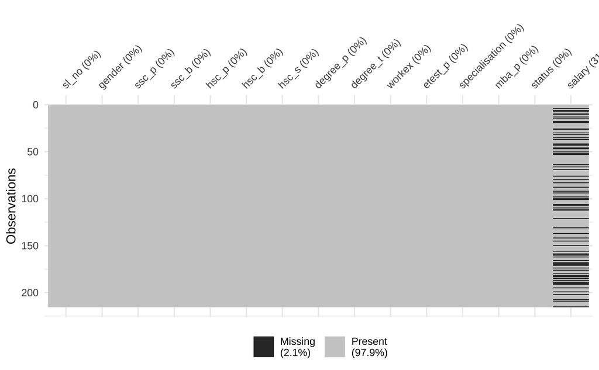

```r
vis_miss(placement_data)
```

As we can see, all 67 missing values belong to the 67 students who did not secure a job placement. Using a simple for loop, I will now impute a 0 instead of NA’s to allow for further analysis and calculations.

```r
placement_data %>%
  filter(status == "Not Placed") %>%
  select(status,salary)
```

| status | salary |
| --- | --- |
| Not Placed | NA |
| Not Placed | NA |
| Not Placed | NA |
| Not Placed | NA |
| Not Placed | NA |
| Not Placed | NA |
| Not Placed | NA |
| Not Placed | NA |
| Not Placed | NA |
| Not Placed | NA |

[output cut: 57 more lines]

```r
for (i in 1:dim(placement_data)[1]){
  if(is.na(placement_data$salary[i])){
    placement_data$salary[i] <- 0
  }
}

# Check to make sure no more missing values
sum(is.na(placement_data))
```

```
[1] 0
```

#### Variable Analysis

Now for the fun part! Let’s look more into some of the variables to see any potential pathways towards deeper insights.

As we can see the gender distribution within the class leans towards a greater number of male students than female students. I chose to display this within a “waffle chart” because I read about them recently and really loved the ease of which they disseminate the information!

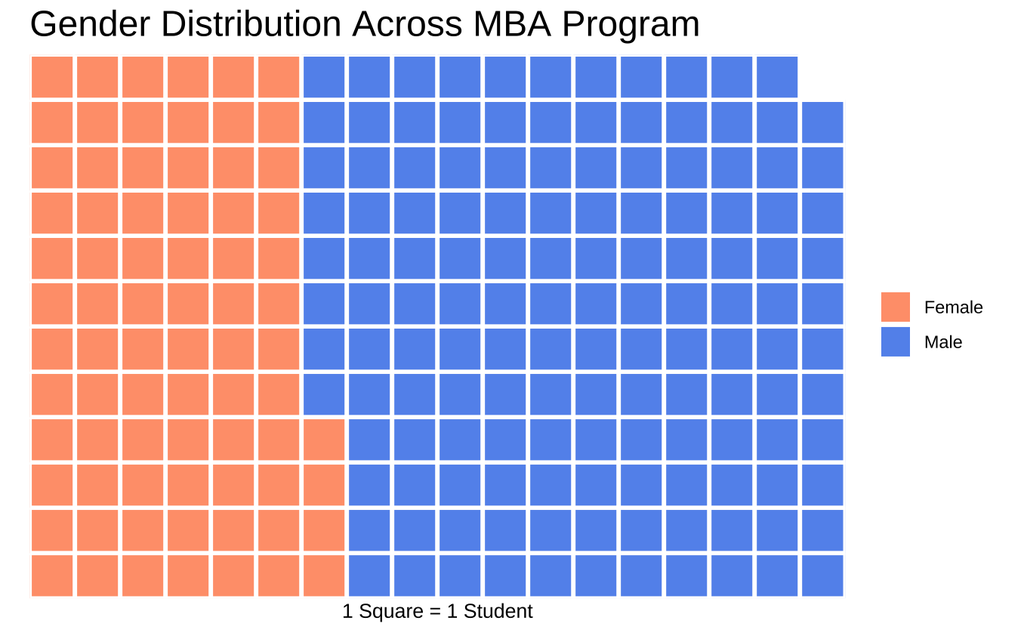

```r
# Try and figure out the glyph stuff...
# font_import()
# loadfonts()
# fonts()[grep("Awesome", fonts())]
#
# waffle(c(50, 30, 15, 5), rows = 5, use_glyph = "music", glyph_size = 6)

waffle_parts <- c(`Female` = dim(filter(placement_data, gender == "F"))[1], `Male` = dim(filter(placement_data, gender == "M"))[1])

waffle(parts = waffle_parts, rows = 12, reverse = F, xlab = "1 Square = 1 Student", title = "Gender Distribution Across MBA Program", colors = c("lightsalmon1", "cornflowerblue"), size = 1)
```

```r
placement_data %>%
  select(hsc_s)
```

| hsc_s |
| --- |
| Commerce |
| Science |
| Arts |
| Science |
| Commerce |
| Science |
| Commerce |
| Science |
| Commerce |
| Commerce |

[output cut: 205 more lines]

```r
levels(placement_data$degree_t)
```

```
[1] "Comm&Mgmt" "Others"    "Sci&Tech"
```

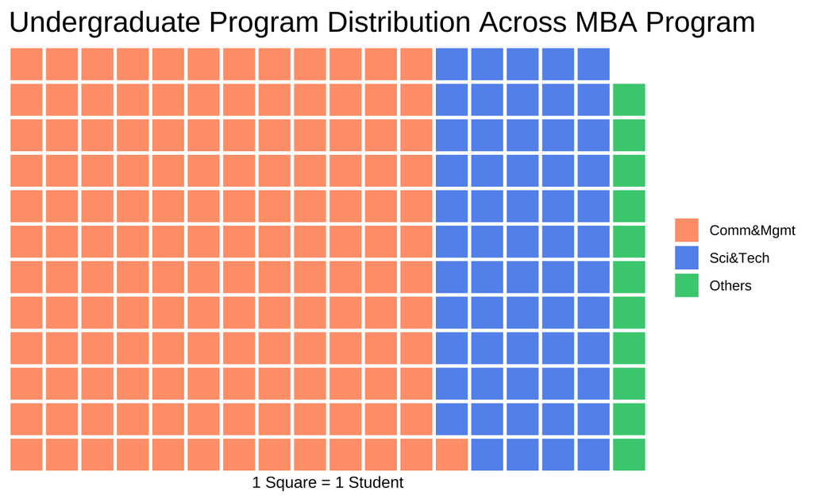

```r
waffle2_parts <- c(`Comm&Mgmt` = dim(filter(placement_data, degree_t == "Comm&Mgmt"))[1],`Sci&Tech` = dim(filter(placement_data, degree_t == "Sci&Tech"))[1],`Others` = dim(filter(placement_data, degree_t == "Others"))[1])

waffle(parts = waffle2_parts, rows = 12, reverse = F, xlab = "1 Square = 1 Student", title = "Undergraduate Program Distribution Across MBA Program", colors = c("lightsalmon1", "cornflowerblue", "seagreen3"), size = 1)
```

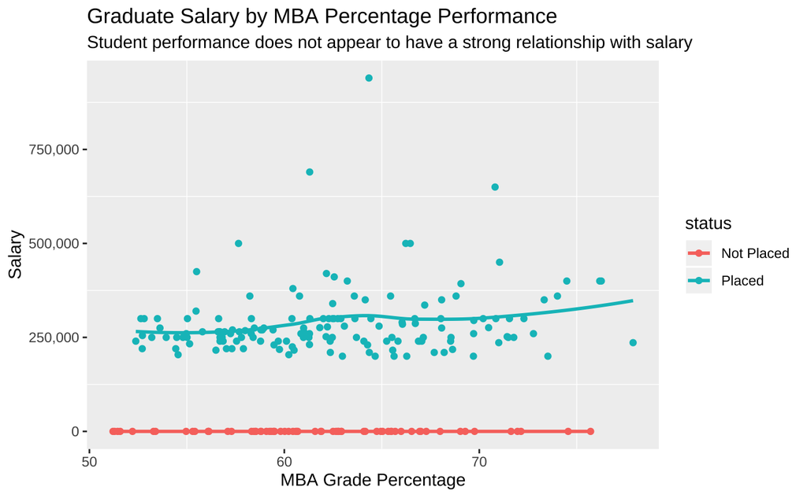

```r
ggplot(placement_data, aes(x = mba_p, y = salary, col = status)) +
  geom_point() +
  ggtitle("Graduate Salary by MBA Percentage Performance",
          subtitle = "Student performance does not appear to have a strong relationship with salary") +
  scale_y_continuous(labels = comma) +
  xlab("MBA Grade Percentage") +
  ylab("Salary") +
  theme(panel.grid.major = element_blank(),
        panel.background = element_rect(fill="gray94", colour=NA)) +
  geom_smooth(se = F)
```

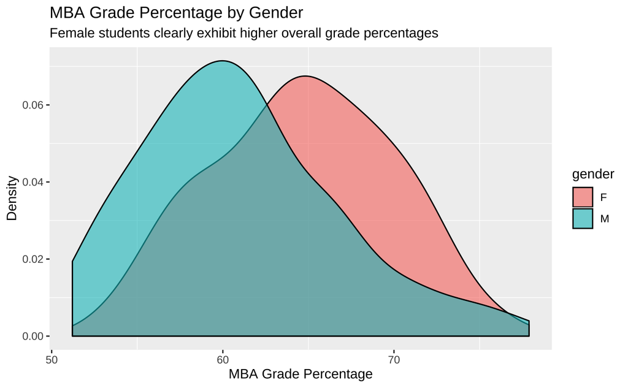

```r
ggplot(placement_data, aes(x = mba_p, fill = gender)) +
  geom_density( col = "black", alpha = 0.6) +
  ggtitle("MBA Grade Percentage by Gender", subtitle = "Female students clearly exhibit higher overall grade percentages") +
  xlab("MBA Grade Percentage") +
  ylab("Density") +
  theme(panel.grid.major = element_blank(),
        panel.background = element_rect(fill="gray94", colour=NA))
```

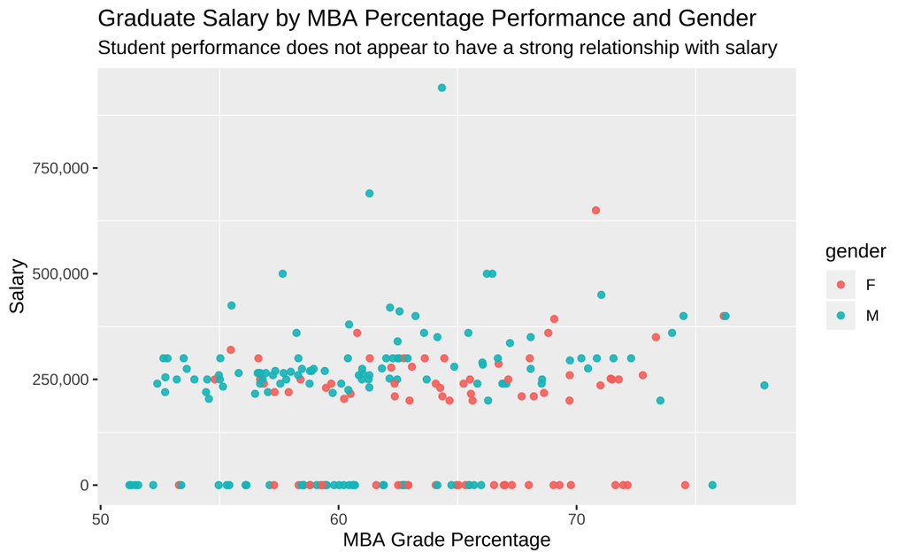

```r
ggplot(placement_data, aes(x = mba_p, y = salary, col = gender)) +
  geom_point(alpha = 0.9) +
  ggtitle("Graduate Salary by MBA Percentage Performance and Gender",
          subtitle = "Student performance does not appear to have a strong relationship with salary") +
  scale_y_continuous(labels = comma) +
  xlab("MBA Grade Percentage") +
  ylab("Salary") +
  theme(panel.grid.major = element_blank(),
        panel.background = element_rect(fill="gray94", colour=NA))
```

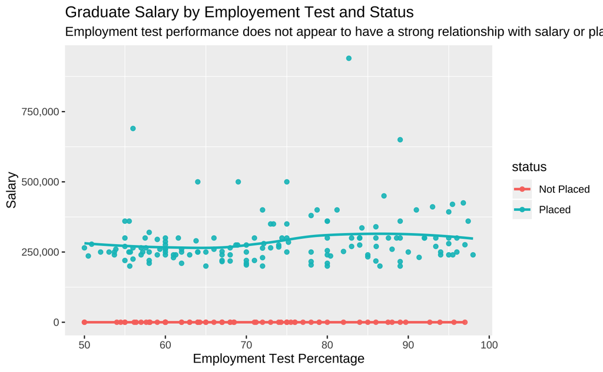

```r
ggplot(placement_data, aes(x = etest_p, y = salary, col = status)) +
  geom_point(alpha = 0.9) +
  ggtitle("Graduate Salary by Employement Test and Status",
          subtitle = "Employment test performance does not appear to have a strong relationship with salary or placement chances") +
  scale_y_continuous(labels = comma) +
  xlab("Employment Test Percentage") +
  ylab("Salary") +
  theme(panel.grid.major = element_blank(),
        panel.background = element_rect(fill="gray94", colour=NA)) +
  geom_smooth(se = F)
```

Did women fair better than men on the employment test? If yes, why are they not getting paid more? We already know they perform better from a GPA standpoint. This visual shows men do in fact perform better on the employment test.

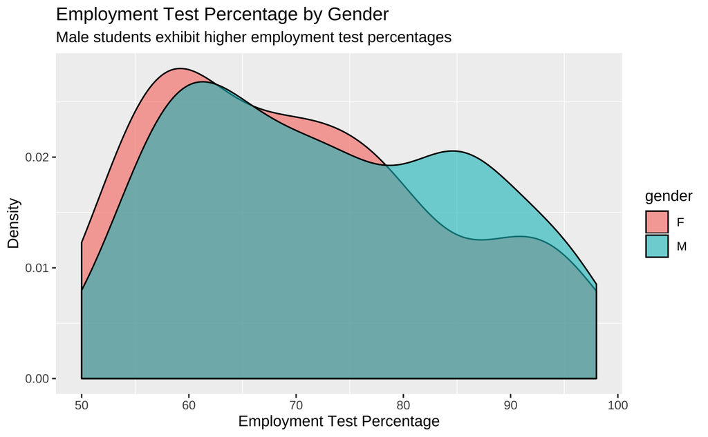

```r
ggplot(placement_data, aes(x = etest_p, fill = gender)) +
  geom_density( col = "black", alpha = 0.6) +
  ggtitle("Employment Test Percentage by Gender", subtitle = "Male students exhibit higher employment test percentages") +
  xlab("Employment Test Percentage") +
  ylab("Density") +
  theme(panel.grid.major = element_blank(),
        panel.background = element_rect(fill="gray94", colour=NA))
```

Specialization effect on salary

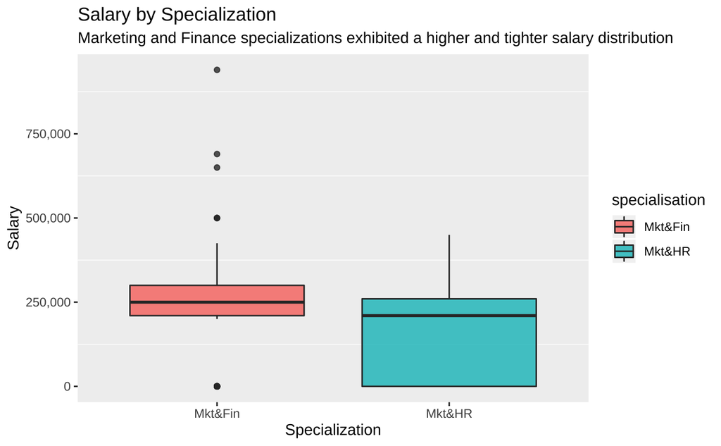

```r
ggplot(placement_data, aes(x = specialisation, y = salary, fill = specialisation)) +
  geom_boxplot(alpha = 0.8) +
  ggtitle("Salary by Specialization", subtitle = "Marketing and Finance specializations exhibited a higher and tighter salary distribution") +
  xlab("Specialization") +
  ylab("Salary") +
  theme(panel.grid.major = element_blank(),
        panel.background = element_rect(fill="gray94", colour=NA)) +
  scale_y_continuous(labels = comma)
```

Analysis on Work Experience

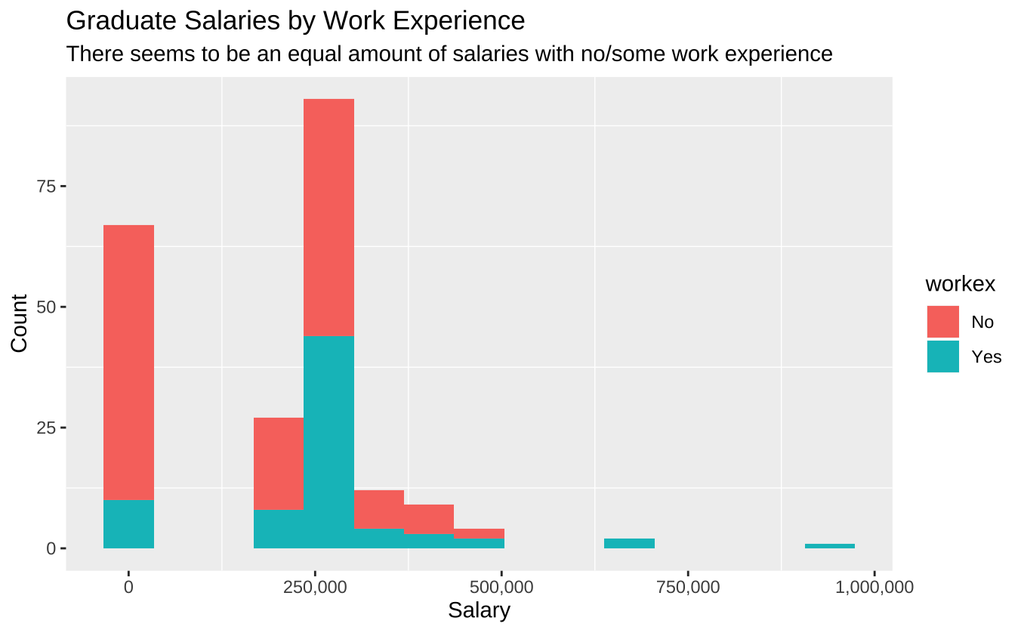

```r
ggplot(placement_data, aes(x = salary, fill = workex)) +
  geom_histogram(bins = 15) +
  scale_x_continuous(labels = comma) +
  ggtitle("Graduate Salaries by Work Experience", subtitle = "There seems to be an equal amount of salaries with no/some work experience") +
  xlab("Salary") +
  ylab("Count") +
  theme(panel.grid.major = element_blank(),
        panel.background = element_rect(fill="gray94", colour=NA))
```

## Model Building

### Logistic Regresion Analysis

By utilizing a logistic regression, we can see which factors have the greatest impact on placement chances.

```r
set.seed(123)
num_samples <- dim(placement_data)[1]
sampling.rate <- 0.7
training <- sample(1:num_samples, sampling.rate * num_samples)
trainingSet <- placement_data[training, ]
testing <- setdiff(1:num_samples,training)
testingSet <- placement_data[testing, ]

glm_fit1 <- glm(status ~. - salary, data = trainingSet, family = "binomial")
summary(glm_fit1)
```

```
Call:
glm(formula = status ~ . - salary, family = "binomial", data = trainingSet)

Deviance Residuals:
     Min        1Q    Median        3Q       Max
-1.93252  -0.13140   0.08428   0.34538   2.19373

Coefficients:
                       Estimate Std. Error z value Pr(>|z|)
(Intercept)          -18.054965   6.443901  -2.802 0.005081 **
sl_no                  0.007572   0.005539   1.367 0.171594
genderM                1.044000   0.798457   1.308 0.191036
ssc_p                  0.206807   0.053579   3.860 0.000113 ***
ssc_bOthers            0.441055   0.856393   0.515 0.606543
hsc_p                  0.138645   0.051344   2.700 0.006928 **
hsc_bOthers            0.375301   0.915172   0.410 0.681741
hsc_sCommerce         -2.321208   1.936951  -1.198 0.230768
hsc_sScience          -0.902060   2.100562  -0.429 0.667605
degree_p               0.178188   0.068239   2.611 0.009021 **
degree_tOthers         0.088005   2.467829   0.036 0.971553
degree_tSci&Tech      -1.960990   1.076903  -1.821 0.068614 .
workexYes              1.997485   0.817176   2.444 0.014510 *
etest_p               -0.026811   0.027500  -0.975 0.329591
specialisationMkt&HR  -0.315263   0.715100  -0.441 0.659310
mba_p                 -0.213472   0.071843  -2.971 0.002965 **
---
Signif. codes:  0 ‘***’ 0.001 ‘**’ 0.01 ‘*’ 0.05 ‘.’ 0.1 ‘ ’ 1

(Dispersion parameter for binomial family taken to be 1)

    Null deviance: 188.061  on 149  degrees of freedom
Residual deviance:  71.229  on 134  degrees of freedom
AIC: 103.23

Number of Fisher Scoring iterations: 7
```

```r
predictions_glm1 <- predict(glm_fit1, testingSet, type = "response")
predictions_glm1 <- ifelse(predictions_glm1 >= 0.5, 1, 0)
anova(glm_fit1, test = "Chisq")
```

```
Analysis of Deviance Table

Model: binomial, link: logit

Response: status

Terms added sequentially (first to last)

               Df Deviance Resid. Df Resid. Dev  Pr(>Chi)
NULL                             149    188.061
sl_no           1    0.025       148    188.035 0.8731428
gender          1    0.807       147    187.228 0.3688709
ssc_p           1   69.768       146    117.460 < 2.2e-16 ***
ssc_b           1    0.318       145    117.142 0.5726594
hsc_p           1   14.912       144    102.230 0.0001127 ***
hsc_b           1    0.035       143    102.195 0.8525001
hsc_s           2    2.844       141     99.352 0.2412763
degree_p        1    3.979       140     95.373 0.0460759 *
degree_t        2    5.123       138     90.250 0.0771757 .
workex          1    7.010       137     83.240 0.0081074 **
etest_p         1    1.076       136     82.164 0.2995744
specialisation  1    0.126       135     82.038 0.7230830
mba_p           1   10.810       134     71.229 0.0010096 **
---
Signif. codes:  0 ‘***’ 0.001 ‘**’ 0.01 ‘*’ 0.05 ‘.’ 0.1 ‘ ’ 1
```

Have to create a new variable to test against the predictions since our outcome is coded in as a 1 or 2 factor. Could also change the initial variable to binary (0,1).

```r
testingSet$status_number <- NA
for (i in 1:dim(testingSet)[1]){
  if(testingSet$status[i] == "Placed"){
    testingSet$status_number[i] <- 1
  } else {
    testingSet$status_number[i] <- 0
  }
}
misclassification_rate <- mean(predictions_glm1 != testingSet$status_number)
print(paste("Accuracy:",1-misclassification_rate))
```

```
[1] "Accuracy: 0.892307692307692"
```

Plot ROC curve and find the AUC.

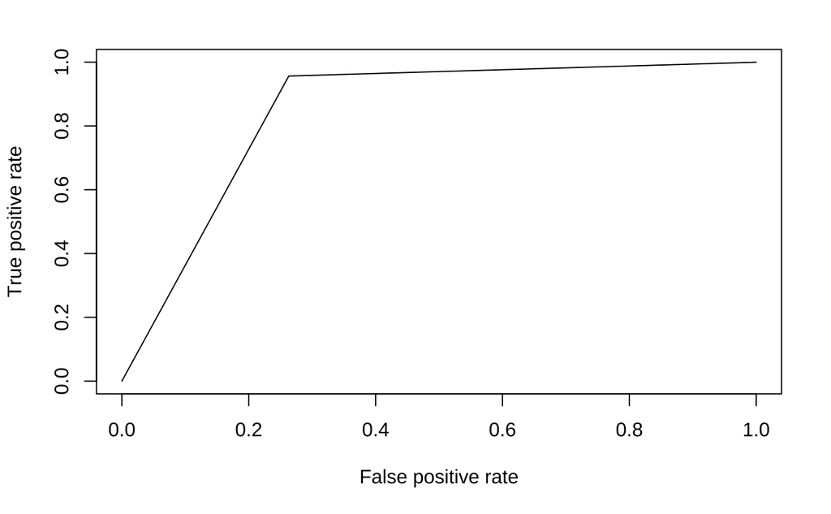

```r
predictions_ROC <- prediction(predictions_glm1, testingSet$status_number)
prf <- performance(predictions_ROC, measure = "tpr", x.measure = "fpr")
plot(prf)
```

```r
auc <- performance(predictions_ROC, measure = "auc")
auc <- auc@y.values[[1]]
auc
```

```
[1] 0.8466819
```

### Linear Regresion Analysis

By utilizing a linear regression, we can see which factors have the greatest impact on graduate salary.

```r
# Create a training and testing set
set.seed(123)
num_samples <- dim(placement_data)[1]
sampling.rate <- 0.7
training <- sample(1:num_samples, sampling.rate * num_samples)
trainingSet <- placement_data[training, ]
testing <- setdiff(1:num_samples,training)
testingSet <- placement_data[testing, ]

lm_fit1 <- lm(salary ~. - status - sl_no, data = trainingSet)
summary(lm_fit1)
```

```
Call:
lm(formula = salary ~ . - status - sl_no, data = trainingSet)

Residuals:
    Min      1Q  Median      3Q     Max
-233966  -75994   -5724   64527  452884

Coefficients:
                      Estimate Std. Error t value Pr(>|t|)
(Intercept)          -365791.7   134558.3  -2.718 0.007420 **
genderM                45767.8    21549.8   2.124 0.035509 *
ssc_p                   4854.3     1214.3   3.998 0.000105 ***
ssc_bOthers            25242.2    24814.2   1.017 0.310855
hsc_p                   3756.2     1197.9   3.136 0.002105 **
hsc_bOthers            -6136.1    24800.5  -0.247 0.804961
hsc_sCommerce         -47879.4    53902.8  -0.888 0.375984
hsc_sScience          -10949.3    56903.9  -0.192 0.847704
degree_p                3324.8     1616.5   2.057 0.041636 *
degree_tOthers         -7571.9    56995.8  -0.133 0.894510
degree_tSci&Tech      -16656.2    29350.8  -0.567 0.571327
workexYes              61424.2    21577.0   2.847 0.005107 **
etest_p                 -492.6      786.6  -0.626 0.532196
specialisationMkt&HR  -24626.3    21638.7  -1.138 0.257107
mba_p                  -3375.6     1880.7  -1.795 0.074918 .
---
Signif. codes:  0 ‘***’ 0.001 ‘**’ 0.01 ‘*’ 0.05 ‘.’ 0.1 ‘ ’ 1

Residual standard error: 115200 on 135 degrees of freedom
Multiple R-squared:  0.4798,    Adjusted R-squared:  0.4258
F-statistic: 8.894 on 14 and 135 DF,  p-value: 1.66e-13
```

Make predictions based on this initial model.

```r
predictions_fit1 <- predict(lm_fit1, testingSet)
error <- predictions_fit1 - testingSet$salary
rmse <- sqrt(mean(error^2))
rmse
```

```
[1] 133304.1
```

Remove hsc_s

```r
lm_fit2 <- lm(salary ~. - status - sl_no - hsc_s, data = trainingSet)
summary(lm_fit2)
```

```
Call:
lm(formula = salary ~ . - status - sl_no - hsc_s, data = trainingSet)

Residuals:
    Min      1Q  Median      3Q     Max
-232339  -76129   -6382   67532  455013

Coefficients:
                      Estimate Std. Error t value Pr(>|t|)
(Intercept)          -394667.2   129169.3  -3.055  0.00270 **
genderM                45115.8    21409.5   2.107  0.03692 *
ssc_p                   4848.3     1172.6   4.135 6.17e-05 ***
ssc_bOthers            21491.0    24333.9   0.883  0.37869
hsc_p                   3418.2     1136.7   3.007  0.00314 **
hsc_bOthers            -2850.9    24157.6  -0.118  0.90623
degree_p                3518.0     1597.3   2.202  0.02931 *
degree_tOthers         23134.8    50742.6   0.456  0.64917
degree_tSci&Tech        7701.9    21985.9   0.350  0.72664
workexYes              61564.0    21435.2   2.872  0.00473 **
etest_p                 -502.1      781.0  -0.643  0.52138
specialisationMkt&HR  -22753.3    21476.9  -1.059  0.29127
mba_p                  -3350.7     1869.0  -1.793  0.07522 .
---
Signif. codes:  0 ‘***’ 0.001 ‘**’ 0.01 ‘*’ 0.05 ‘.’ 0.1 ‘ ’ 1

Residual standard error: 115200 on 137 degrees of freedom
Multiple R-squared:  0.4716,    Adjusted R-squared:  0.4253
F-statistic: 10.19 on 12 and 137 DF,  p-value: 4.156e-14
```

```r
predictions_fit2 <- predict(lm_fit2, testingSet)
error2 <- predictions_fit2 - testingSet$salary
rmse2 <- sqrt(mean(error2^2))
rmse2
```

```
[1] 131232.8
```

```r
lm_fit3 <- lm(salary ~. - status - sl_no - hsc_s - degree_t, data = trainingSet)
summary(lm_fit3)
```

```
Call:
lm(formula = salary ~ . - status - sl_no - hsc_s - degree_t,
    data = trainingSet)

Residuals:
    Min      1Q  Median      3Q     Max
-229737  -73658   -5878   65233  456884

Coefficients:
                      Estimate Std. Error t value Pr(>|t|)
(Intercept)          -390623.5   126005.2  -3.100  0.00234 **
genderM                45594.1    20584.9   2.215  0.02839 *
ssc_p                   4979.3     1127.5   4.416    2e-05 ***
ssc_bOthers            22839.7    24055.0   0.949  0.34402
hsc_p                   3290.6     1094.1   3.007  0.00313 **
hsc_bOthers            -4345.8    23781.9  -0.183  0.85527
degree_p                3445.4     1566.2   2.200  0.02947 *
workexYes              61763.3    21251.6   2.906  0.00426 **
etest_p                 -509.0      774.4  -0.657  0.51211
specialisationMkt&HR  -21734.2    21232.6  -1.024  0.30779
mba_p                  -3287.1     1846.1  -1.781  0.07717 .
---
Signif. codes:  0 ‘***’ 0.001 ‘**’ 0.01 ‘*’ 0.05 ‘.’ 0.1 ‘ ’ 1

Residual standard error: 114500 on 139 degrees of freedom
Multiple R-squared:  0.4705,    Adjusted R-squared:  0.4324
F-statistic: 12.35 on 10 and 139 DF,  p-value: 3.775e-15
```

```r
predictions_fit3 <- predict(lm_fit3, testingSet)
error3 <- predictions_fit3 - testingSet$salary
rmse3 <- sqrt(mean(error3^2))
rmse3
```

```
[1] 130074.1
```

```r
lm_fit4 <- lm(salary ~. - status - sl_no - hsc_s - degree_t - ssc_b, data = trainingSet)
summary(lm_fit4)
```

```
Call:
lm(formula = salary ~ . - status - sl_no - hsc_s - degree_t -
    ssc_b, data = trainingSet)

Residuals:
    Min      1Q  Median      3Q     Max
-226221  -71065   -7958   65864  450611

Coefficients:
                     Estimate Std. Error t value Pr(>|t|)
(Intercept)           -386845     125898  -3.073  0.00255 **
genderM                 45645      20578   2.218  0.02815 *
ssc_p                    5226       1097   4.764 4.69e-06 ***
hsc_p                    2995       1049   2.856  0.00494 **
hsc_bOthers              8344      19664   0.424  0.67197
degree_p                 3435       1566   2.194  0.02988 *
workexYes               58366      20941   2.787  0.00606 **
etest_p                  -575        771  -0.746  0.45701
specialisationMkt&HR   -25604      20830  -1.229  0.22108
mba_p                   -3125       1838  -1.700  0.09127 .
---
Signif. codes:  0 ‘***’ 0.001 ‘**’ 0.01 ‘*’ 0.05 ‘.’ 0.1 ‘ ’ 1

Residual standard error: 114500 on 140 degrees of freedom
Multiple R-squared:  0.467, Adjusted R-squared:  0.4328
F-statistic: 13.63 on 9 and 140 DF,  p-value: 1.499e-15
```

```r
predictions_fit4 <- predict(lm_fit4, testingSet)
error4 <- predictions_fit4 - testingSet$salary
rmse4 <- sqrt(mean(error4^2))
rmse4
```

```
[1] 129975.7
```

Here we see employment test is very insignificant in terms of predicting salary.

```r
lm_fit5 <- lm(salary ~. - status - sl_no - hsc_s - degree_t - ssc_b - hsc_b, data = trainingSet)
summary(lm_fit5)
```

```
Call:
lm(formula = salary ~ . - status - sl_no - hsc_s - degree_t -
    ssc_b - hsc_b, data = trainingSet)

Residuals:
    Min      1Q  Median      3Q     Max
-224378  -68866  -10523   68099  445725

Coefficients:
                      Estimate Std. Error t value Pr(>|t|)
(Intercept)          -389365.2   125391.7  -3.105  0.00230 **
genderM                46492.6    20420.8   2.277  0.02431 *
ssc_p                   5223.8     1093.7   4.776 4.42e-06 ***
hsc_p                   2973.4     1044.3   2.847  0.00507 **
degree_p                3484.9     1556.7   2.239  0.02674 *
workexYes              58138.1    20873.0   2.785  0.00608 **
etest_p                 -573.7      768.7  -0.746  0.45672
specialisationMkt&HR  -25113.5    20737.9  -1.211  0.22792
mba_p                  -3039.1     1821.1  -1.669  0.09738 .
---
Signif. codes:  0 ‘***’ 0.001 ‘**’ 0.01 ‘*’ 0.05 ‘.’ 0.1 ‘ ’ 1

Residual standard error: 114100 on 141 degrees of freedom
Multiple R-squared:  0.4664,    Adjusted R-squared:  0.4361
F-statistic:  15.4 on 8 and 141 DF,  p-value: 3.989e-16
```

```r
predictions_fit5 <- predict(lm_fit5, testingSet)
error5 <- predictions_fit5 - testingSet$salary
rmse5 <- sqrt(mean(error5^2))
rmse5
```

```
[1] 129282.9
```

```r
lm_fit6 <- lm(salary ~. - status - sl_no - hsc_s - degree_t - ssc_b - hsc_b - etest_p, data = trainingSet)
summary(lm_fit6)
```

```
Call:
lm(formula = salary ~ . - status - sl_no - hsc_s - degree_t -
    ssc_b - hsc_b - etest_p, data = trainingSet)

Residuals:
    Min      1Q  Median      3Q     Max
-214466  -70858  -10837   63330  454189

Coefficients:
                     Estimate Std. Error t value Pr(>|t|)
(Intercept)           -408854     122451  -3.339  0.00107 **
genderM                 44610      20233   2.205  0.02907 *
ssc_p                    5243       1092   4.803 3.93e-06 ***
hsc_p                    2869       1033   2.777  0.00623 **
degree_p                 3374       1547   2.181  0.03086 *
workexYes               60063      20681   2.904  0.00427 **
specialisationMkt&HR   -21967      20273  -1.084  0.28040
mba_p                   -3201       1805  -1.773  0.07832 .
---
Signif. codes:  0 ‘***’ 0.001 ‘**’ 0.01 ‘*’ 0.05 ‘.’ 0.1 ‘ ’ 1

Residual standard error: 113900 on 142 degrees of freedom
Multiple R-squared:  0.4643,    Adjusted R-squared:  0.4378
F-statistic: 17.58 on 7 and 142 DF,  p-value: < 2.2e-16
```

```r
predictions_fit6 <- predict(lm_fit6, testingSet)
error6 <- predictions_fit6 - testingSet$salary
rmse6 <- sqrt(mean(error6^2))
rmse6
```

```
[1] 128485.3
```

```r
lm_fit7 <- lm(salary ~. - status - sl_no - hsc_s - degree_t - ssc_b - hsc_b - etest_p - degree_p, data = trainingSet)
summary(lm_fit7)
```

```
Call:
lm(formula = salary ~ . - status - sl_no - hsc_s - degree_t -
    ssc_b - hsc_b - etest_p - degree_p, data = trainingSet)

Residuals:
    Min      1Q  Median      3Q     Max
-218135  -80171   -9032   68455  427856

Coefficients:
                     Estimate Std. Error t value Pr(>|t|)
(Intercept)           -288035     110624  -2.604  0.01019 *
genderM                 37304      20214   1.845  0.06704 .
ssc_p                    5883       1065   5.523 1.53e-07 ***
hsc_p                    3274       1030   3.180  0.00181 **
workexYes               59259      20947   2.829  0.00534 **
specialisationMkt&HR   -29252      20257  -1.444  0.15092
mba_p                   -2547       1803  -1.413  0.15998
---
Signif. codes:  0 ‘***’ 0.001 ‘**’ 0.01 ‘*’ 0.05 ‘.’ 0.1 ‘ ’ 1

Residual standard error: 115400 on 143 degrees of freedom
Multiple R-squared:  0.4463,    Adjusted R-squared:  0.4231
F-statistic: 19.21 on 6 and 143 DF,  p-value: 2.416e-16
```

```r
predictions_fit7 <- predict(lm_fit7, testingSet)
error7 <- predictions_fit7 - testingSet$salary
rmse7 <- sqrt(mean(error7^2))
rmse7
```

```
[1] 129733.8
```

MBA percentage still not showing much signifiance.

```r
lm_fit8 <- lm(salary ~. - status - sl_no - hsc_s - degree_t - ssc_b - hsc_b - etest_p - specialisation - mba_p, data = trainingSet)
summary(lm_fit8)
```

```
Call:
lm(formula = salary ~ . - status - sl_no - hsc_s - degree_t -
    ssc_b - hsc_b - etest_p - specialisation - mba_p, data = trainingSet)

Residuals:
    Min      1Q  Median      3Q     Max
-250754  -71509   -5704   64659  461804

Coefficients:
            Estimate Std. Error t value Pr(>|t|)
(Intercept)  -579982      91739  -6.322 3.05e-09 ***
genderM        55132      19760   2.790  0.00598 **
ssc_p           4920       1087   4.528 1.24e-05 ***
hsc_p           2704       1016   2.661  0.00868 **
degree_p        3198       1518   2.107  0.03684 *
workexYes      59652      20234   2.948  0.00373 **
---
Signif. codes:  0 ‘***’ 0.001 ‘**’ 0.01 ‘*’ 0.05 ‘.’ 0.1 ‘ ’ 1

Residual standard error: 114900 on 144 degrees of freedom
Multiple R-squared:  0.4477,    Adjusted R-squared:  0.4285
F-statistic: 23.34 on 5 and 144 DF,  p-value: < 2.2e-16
```

```r
predictions_fit8 <- predict(lm_fit8, testingSet)
error8 <- predictions_fit8 - testingSet$salary
rmse8 <- sqrt(mean(error8^2))
rmse8
```

```
[1] 131393
```

# As a final result, it appears as though the most important factors in higher salary are your academic performance, whether you had previous work experience, and whether or not you are male, with the latter leading to a ~55000 increase in salary. This would be interesting to investigate further to understand why males are given such a higher wage on average, and could lend itself to gender wage gap conversations!